# 5: Introduction to machine learning - Exercise

Rohit Koonireddy

21 10 2023

### Intro

Now that you have learned the basics of LM, GLM and unsupervised machine learning you should be able to solve this exercise.

You will again work on the bird data set you know already from the tutorial. In addition, we will provide you with a number of additional species occurring in Switzerland. You will have land cover information (e.g. forest cover) for each grid cell as well as basic environmental data (e.g. temperature).

Imagine you are researching bird species in Switzerland and you want to identify the variables driving the patterns of species richness.

### You will have these aims:

#### 1. Load additional bird species into the data.

```
1. Merge the environmental and bird variables and summarize your environmental data set and explain what you see.
2. Are there any correlations or missing data?
3. If so, try to fill the missing values if possible, otherwise discard the rows. Find the most and least common bird species in the data.
```

```r
# load the data set, most data you will encounter will be saved either as .txt or.csv format
bird_env_mat <- read.csv(file = "data/bird_env_dat.csv")

# change all "." in variable names to "_", in order to avoid confusion
colnames(bird_env_mat) <- gsub("\\.","_", colnames(bird_env_mat))

# Set the path to the folder containing the text files
folder_path <- "data/bird_swiss/"

# List all text files in the folder
file_list <- list.files(folder_path, pattern = ".txt", full.names = TRUE)

# Initialize an empty data frame to store the merged data
merged_df <- data.frame()

# Loop through each file and read it into a data frame
for (file in file_list) {
  temp_df <- read.table(file, sep = ";", header = TRUE)
  colnames(temp_df) <- gsub("\\.","_", colnames(temp_df))
  file_name <- tools::file_path_sans_ext(basename(file))
  colnames(temp_df)[colnames(temp_df) == "occ"] <- file_name
  # Merge the temporary data frame with the merged data frame
  if (nrow(merged_df) == 0) {
    # If merged_df is empty, assign the contents of temp_df
    merged_df <- temp_df
  } else {
    # Otherwise, merge by common columns (adjust as needed)
    merged_df <- merge(merged_df, temp_df, by =c("KoordID","x","y"), all = TRUE)
  }

}

all_birds_df <- merge(merged_df,bird_env_mat,by =c("KoordID","x","y"))
colnames(all_birds_df) <- gsub(" ", "_", tolower(colnames(all_birds_df)))

#remove the repeated ones <- whinchat is not there in the texts provided
all_birds_df <- all_birds_df[, !(colnames(all_birds_df) %in% c("ptarmigan", "dipper"))]

dim(all_birds_df)
```

```
## [1] 472  90
```

```r
#str(all_birds_df)
```

#### 2. Calculate Species richness

1. How many species do we have in total, what does this tell us about the species composition?
2. Calculate species richness per grid cell (add a new column with the variable species richness).

```r
#create df with only birds
only_birds_df <- all_birds_df[, !(colnames(all_birds_df) %in% c("koordid","x", "y", "elev_birds","prec_birds",
                                                                "temp_birds","est_slope","forest_edge_sum",
                                                                "forest_sum", "rassland_sum", "water_dist",
                                                                "buildings_sum", "grassland_sum"))]

birds_count <- data.frame(colSums(only_birds_df))
birds_count$bird_species_name <- rownames(birds_count)
rownames(birds_count) <- NULL
colnames(birds_count) <- c("presence_count","bird_species_name")
birds_count<- birds_count[,c("bird_species_name","presence_count")]
birds_count
```

```
##                bird_species_name presence_count
## 1                accipiter_nisus             84
## 2            aegithalos_caudatus            177
## 3                alauda_arvensis            103
## 4             anas_platyrhynchos            122
## 5              anthus_spinoletta            153
## 6               anthus_trivialis            169
## 7                      apus_apus            119
## 8                    buteo_buteo            305
## 9              carduelis_cabaret             79
## 10           carduelis_cannabina            140
## 11           carduelis_carduelis            249
## 12             carduelis_chloris            252
## 13              carduelis_spinus             64
## 14         certhia_brachydactyla            209
```

[output cut: 64 more lines]

There are 78 bird species.

Include the speices richness column

```r
library(dplyr)
#species richness inclusion
all_birds_df <- all_birds_df %>% mutate(species_richness = rowSums(dplyr::select(., accipiter_nisus:whinchat)))
print(dim(all_birds_df))
```

```
## [1] 472  91
```

```r
#head(all_birds_df)
```

Check for species presence in on a map

```r
print(colnames(all_birds_df))
```

```
##  [1] "koordid"                       "x"
##  [3] "y"                             "accipiter_nisus"
##  [5] "aegithalos_caudatus"           "alauda_arvensis"
##  [7] "anas_platyrhynchos"            "anthus_spinoletta"
##  [9] "anthus_trivialis"              "apus_apus"
## [11] "buteo_buteo"                   "carduelis_cabaret"
## [13] "carduelis_cannabina"           "carduelis_carduelis"
## [15] "carduelis_chloris"             "carduelis_spinus"
## [17] "certhia_brachydactyla"         "certhia_familiaris"
## [19] "cinclus_cinclus"               "coccothraustes_coccothraustes"
## [21] "columba_palumbus"              "corvus_corax"
## [23] "corvus_corone"                 "cuculus_canorus"
## [25] "delichon_urbicum"              "dendrocopos_major"
## [27] "dryocopus_martius"             "emberiza_citrinella"
## [29] "erithacus_rubecula"            "falco_tinnunculus"
```

[output cut: 31 more lines]

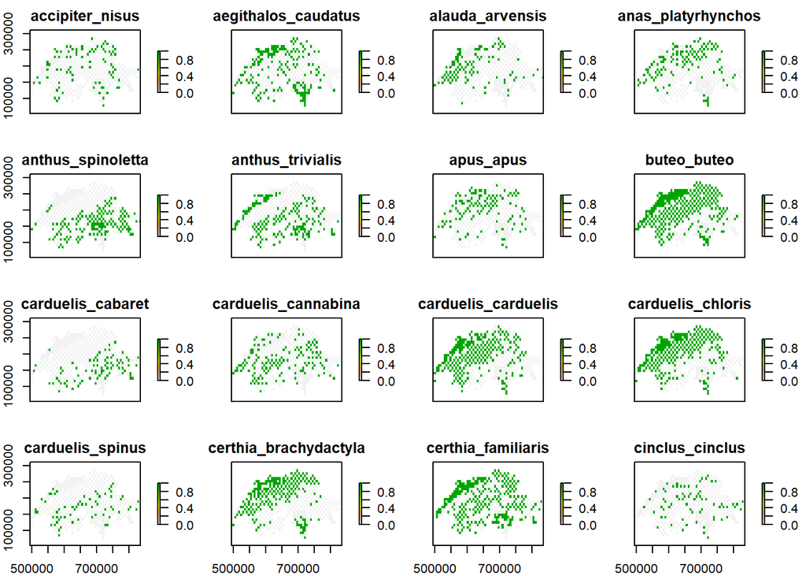

```r
#graphs for all species
# loading the raster library
library("raster")
raster::plot(raster::rasterFromXYZ(all_birds_df[,2:21]))
```

```r
#segregate the fields that are needed
rel_birds_df_1 <- all_birds_df[,colnames(all_birds_df) %in% c("elev_birds","prec_birds","temp_birds" ,"est_slope",
                                            "forest_edge_sum","forest_sum","grassland_sum",
                                            "water_dist","buildings_sum","species_richness")]


rel_birds_df_2 <- all_birds_df[,colnames(all_birds_df) %in% c("elev_birds","prec_birds","est_slope",
                                            "forest_edge_sum","forest_sum","grassland_sum",

                                                                                        "water_dist","buildings_sum","species_richness")]
########
# Calculate the number of NA values in each column
nas_per_column_1 <- colSums(is.na(rel_birds_df_1))

print("NA columns for matrix with temp_birds column")
```

```
## [1] "NA columns for matrix with temp_birds column"
```

```r
# Print the columns and the number of NAs in each column for columns with NAs
for (col_name in colnames(rel_birds_df_1)) {
  na_count <- nas_per_column_1[col_name]
  if (na_count > 0) {
    cat("Column:", col_name, "- Number of NAs:", na_count, "\n")
  }
}
```

```
## Column: temp_birds - Number of NAs: 85
```

```r
#remove the NA rows -> not being so many
rel_birds_df_2 <- na.omit(rel_birds_df_2)
print("NA columns for matrix without temp_birds column")
```

```
## [1] "NA columns for matrix without temp_birds column"
```

```r
#######
########
# Calculate the number of NA values in each column
nas_per_column_2 <- colSums(is.na(rel_birds_df_2))

print("NA columns for matrix with temp_birds column")
```

```
## [1] "NA columns for matrix with temp_birds column"
```

```r
# Print the columns and the number of NAs in each column for columns with NAs
for (col_name in colnames(rel_birds_df_2)) {
  na_count <- nas_per_column_2[col_name]
  if (na_count > 0) {
    cat("Column:", col_name, "- Number of NAs:", na_count, "\n")
  }
}

#remove the NA rows -> not being so many
rel_birds_df_1 <- na.omit(rel_birds_df_1)
print("Dimensions of matrix after removing the NA rows")
```

```
## [1] "Dimensions of matrix after removing the NA rows"
```

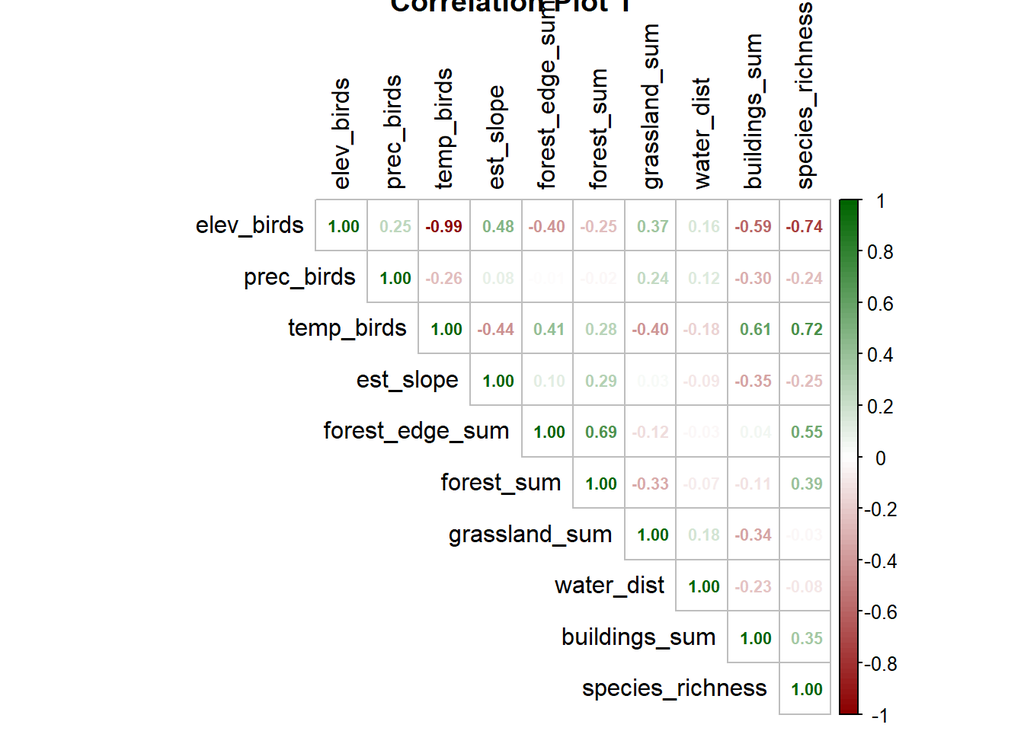

```r
#######


#check for correlation
require("corrplot")
library(corrplot)
#check for correlation
correlation_matrix_1 <- cor(rel_birds_df_1)
correlation_matrix_2 <- cor(rel_birds_df_2)

par(mai = c(1, 1, 1, 1))
par(pin = c(6, 4))


# First Correlation Plot
corrplot(correlation_matrix_1, method = "number", use = "complete",
         tl.col = "black", type = "upper", tl.srt = 90,
         diag = TRUE, sig.level = 0.05, insig = "blank",
         addCoef.col = "black", number.cex = 0.7,
         main = "Correlation Plot 1",
         col = colorRampPalette(c("darkred", "white", "darkgreen"))(100),
         lim = c(-1, 1))
```

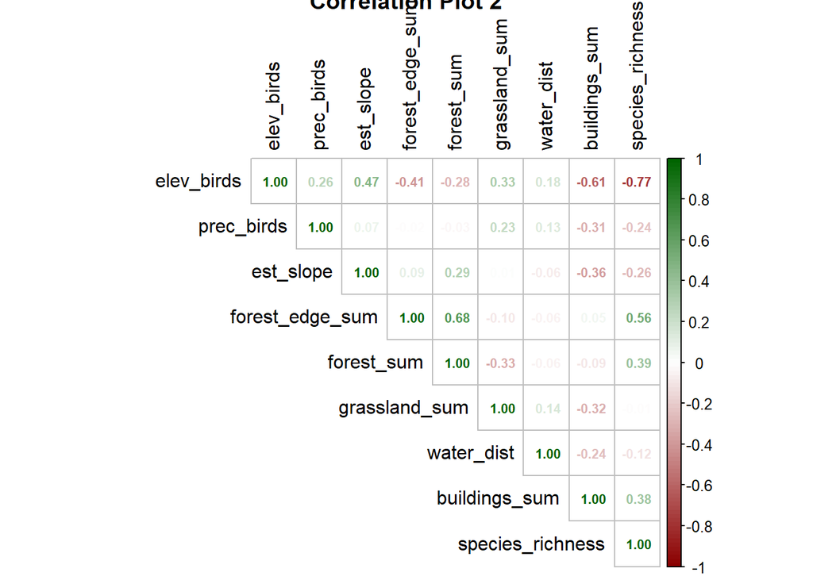

```r
plot.new()
# Second Correlation Plot
corrplot(correlation_matrix_2, method = "number", use = "complete",
         tl.col = "black", type = "upper", tl.srt = 90,
         diag = TRUE, sig.level = 0.05, insig = "blank",
         addCoef.col = "black", number.cex = 0.7,
         main = "Correlation Plot 2",
         col = colorRampPalette(c("darkred", "white", "darkgreen"))(100),
         lim = c(-1, 1))
```

```r
# Reset the layout to its default (1 plot per window)
par(mfrow = c(1, 1))
```

Based on the correlation plots, we see that removing the additional 85 rows of data doesn’t seem to affect the overall correlation matrix. However, temp_birds seem to have a strong and significant correlation to species richness. So use the temp_birds column too and use it further for analysis.

```r
# we copy the rel_birds_df_1 to comparison_df
bird_model_small <- rel_birds_df_1
print(dim(bird_model_small))
```

```
## [1] 387  10
```

Here we see that we have the - KoordID: a unique ID for each sampling location. It is composed of the first three figures of the x- and y-coordinates (km) - x: Longitude coordinate of each gridcell - y: Latitude coordinate of each gridcell Environmental variables that have been extracted from rasters or shapefiles - elev_birds: elevation extracted from the gridcell, m - prec_birds: precipitation extracted from the gridcell, mm - temp_birds: temperature extracted from the Chelsea temperature grid, C° - forest_edge_sum: percentage of forest edge per gridcell - forest_sum: percentage of forest per gridcell - grassland_sum: percentage of grassland per gridcell - water_dist: distance to nearest body of water per gridcell - buildings_sum: sum of buildings within the grid cell

#### 3. Build a model to explain species richness by applying a GLM with either gaussian, binomial of poisson family and the right link-function

[output not shown]

```r
colnames(bird_model_small)
```

```
##  [1] "elev_birds"       "prec_birds"       "temp_birds"       "est_slope"
##  [5] "forest_edge_sum"  "forest_sum"       "grassland_sum"    "water_dist"
##  [9] "buildings_sum"    "species_richness"
```

```r
#checking model goodness
lm1 <- lm(species_richness ~ elev_birds + prec_birds + temp_birds+ est_slope  + forest_edge_sum + forest_sum + grassland_sum + water_dist + buildings_sum, data = all_birds_df)
Sum_mod <- summary(lm1)
print(Sum_mod)
```

```
##
## Call:
## lm(formula = species_richness ~ elev_birds + prec_birds + temp_birds +
##     est_slope + forest_edge_sum + forest_sum + grassland_sum +
##     water_dist + buildings_sum, data = all_birds_df)
##
## Residuals:
##      Min       1Q   Median       3Q      Max
## -19.0622  -4.3042   0.3447   4.6114  17.3345
##
## Coefficients:
##                   Estimate Std. Error t value Pr(>|t|)
## (Intercept)      7.730e+01  1.423e+01   5.432 1.00e-07 ***
## elev_birds      -2.243e-02  3.619e-03  -6.198 1.50e-09 ***
## prec_birds      -1.322e-02  2.873e-03  -4.602 5.74e-06 ***
## temp_birds      -1.621e+00  6.526e-01  -2.483 0.013456 *
## est_slope        8.032e-02  5.901e-02   1.361 0.174331
## forest_edge_sum  1.967e-01  5.072e-02   3.878 0.000124 ***
## forest_sum       1.072e-01  2.102e-02   5.098 5.44e-07 ***
## grassland_sum    2.240e-01  2.081e-02  10.765  < 2e-16 ***
## water_dist       4.226e-05  1.305e-04   0.324 0.746342
## buildings_sum    1.812e-02  1.269e-02   1.427 0.154269
## ---
## Signif. codes:  0 '***' 0.001 '**' 0.01 '*' 0.05 '.' 0.1 ' ' 1
##
## Residual standard error: 6.861 on 377 degrees of freedom
##   (85 observations deleted due to missingness)
## Multiple R-squared:  0.7338, Adjusted R-squared:  0.7275
## F-statistic: 115.5 on 9 and 377 DF,  p-value: < 2.2e-16
```

```r
names(Sum_mod)
```

```
##  [1] "call"          "terms"         "residuals"     "coefficients"
##  [5] "aliased"       "sigma"         "df"            "r.squared"
##  [9] "adj.r.squared" "fstatistic"    "cov.unscaled"  "na.action"
```

```r
Sum_mod$coefficients
```

```
##                      Estimate   Std. Error   t value     Pr(>|t|)
## (Intercept)      7.730255e+01 1.423080e+01  5.432058 1.001018e-07
## elev_birds      -2.242848e-02 3.618846e-03 -6.197689 1.503363e-09
## prec_birds      -1.321823e-02 2.872546e-03 -4.601573 5.736935e-06
## temp_birds      -1.620553e+00 6.526118e-01 -2.483181 1.345555e-02
## est_slope        8.031784e-02 5.901447e-02  1.360986 1.743312e-01
## forest_edge_sum  1.967177e-01 5.072161e-02  3.878380 1.240553e-04
## forest_sum       1.071866e-01 2.102406e-02  5.098284 5.436234e-07
## grassland_sum    2.240142e-01 2.080949e-02 10.765001 9.592852e-24
## water_dist       4.225678e-05 1.305418e-04  0.323703 7.463424e-01
## buildings_sum    1.811580e-02 1.269074e-02  1.427482 1.542687e-01
```

```r
r2 <- Sum_mod$r.squared
adj_r2 <- Sum_mod$adj.r.squared
Sum_mod$adj.r.squared
```

```
## [1] 0.7274523
```

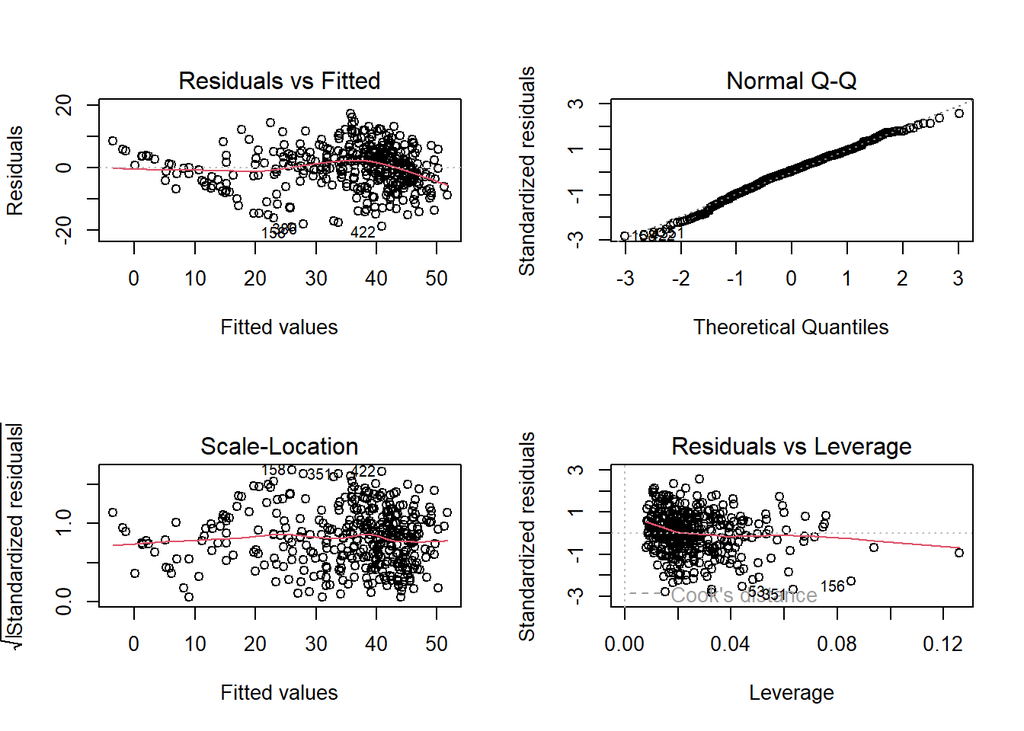

```r
par(mfrow = c(2, 2))
plot(lm1)
```

```r
all_birds_df$predic_temp <- predict.lm(lm1, all_birds_df)


#for 2000m elevation, 10°C temp, 600mm precipitation, 10 for slope, 20 forest.edge, 50 forest, 55 grassland, 2300m distance to water, 4 buildings.
to_predict_on_data <- data.frame(elev_birds = 2000, prec_birds = 600, temp_birds = 10, est_slope = 10,
                                 forest_edge_sum = 20, forest_sum = 50, grassland_sum = 55,
                                 water_dist = 2300, buildings_sum = 4)

predicted_species_richness <- predict(lm1, newdata = to_predict_on_data)
print("Predicted value for given blocks:")
```

```
## [1] "Predicted value for given blocks:"
```

```r
print(predicted_species_richness)
```

```
##        1
## 30.89642
```

Through multi-variate linear regression, we get a value of ~31 birds in the given setting. Also, we see that the following axes are significant (p<0.05) drives of the species_richness : elev_birds,prec_birds,temp_birds,forest_edge_sum, forest_sum,grassland_sum. You can see the R-squared at 0.7338 and adjusted r-squared at 0.7275. The value of 31 bird species seems reasonable but it’s important to critically assess this result. The prediction of 31 species appears high given the relatively low temperature of 10°C. This suggests that the model might not fully account for the temperature constraint on bird diversity. Additionally, the prediction assumes all conditions are met simultaneously, which may not reflect real-world ecological dynamics. The actual species richness could be influenced by more complex interactions and specific regional factors.

#### 4. PCAs can not only inform you on correlations within data, but can be powerful in creating “independent” variables

```
1. Run a PCA on the variables, extract the axes values for all axes you need to explain more than 50% of the variance, and then use these axes in a GLM with species richness.
2. How could you interpret the results of this model?
3. compared to the GLM with all the environmental variables? Elaborate on the difficulties of this approach.
```

```r
library (ade4)
names(bird_model_small)
```

```
##  [1] "elev_birds"       "prec_birds"       "temp_birds"       "est_slope"
##  [5] "forest_edge_sum"  "forest_sum"       "grassland_sum"    "water_dist"
##  [9] "buildings_sum"    "species_richness"
```

```r
bird_pca_dudi <- dudi.pca(bird_model_small[, !(colnames(bird_model_small) %in% "species_richness")],
                         scale = T, center = T,
                         scannf = FALSE, nf = 9)


print("PCA Summary")
```

```
## [1] "PCA Summary"
```

```r
class(bird_pca_dudi)
```

```
## [1] "pca"  "dudi"
```

```r
summary(bird_pca_dudi) #call a summary screen for the PCA
```

```
## Class: pca dudi
## Call: dudi.pca(df = bird_model_small[, !(colnames(bird_model_small) %in%
##     "species_richness")], center = T, scale = T, scannf = FALSE,
##     nf = 9)
##
## Total inertia: 9
##
## Eigenvalues:
##     Ax1     Ax2     Ax3     Ax4     Ax5
##  3.3246  1.8474  1.1928  0.8699  0.7290
##
## Projected inertia (%):
##     Ax1     Ax2     Ax3     Ax4     Ax5
##  36.940  20.527  13.253   9.665   8.100
##
## Cumulative projected inertia (%):
##     Ax1   Ax1:2   Ax1:3   Ax1:4   Ax1:5
##   36.94   57.47   70.72   80.39   88.49
##
## (Only 5 dimensions (out of 9) are shown)
```

```r
print("Eigen values")
```

```
## [1] "Eigen values"
```

```r
bird_pca_dudi$eig
```

```
## [1] 3.324640960 1.847417248 1.192808453 0.869867135 0.728960930 0.489704071
## [7] 0.314038301 0.222788414 0.009774489
```

```r
sum(bird_pca_dudi$eig)
```

```
## [1] 9
```

```r
# this gets you the eigenvalues of the individual axes

print("Percentage capture")
```

```
## [1] "Percentage capture"
```

```r
perc <- round((bird_pca_dudi$eig/sum(bird_pca_dudi$eig))*100,2)
names(bird_pca_dudi)
```

```
##  [1] "tab"  "cw"   "lw"   "eig"  "rank" "nf"   "c1"   "li"   "co"   "l1"
## [11] "call" "cent" "norm"
```

```r
perc
```

```
## [1] 36.94 20.53 13.25  9.67  8.10  5.44  3.49  2.48  0.11
```

```r
sum(perc)
```

```
## [1] 100.01
```

```r
cumsum(perc)
```

```
## [1]  36.94  57.47  70.72  80.39  88.49  93.93  97.42  99.90 100.01
```

```r
bird_pca_dudi$co
```

```
##                      Comp1       Comp2       Comp3       Comp4       Comp5
## elev_birds      -0.9372685 -0.07673780  0.21027386 -0.07537040  0.04244042
## prec_birds      -0.3889675 -0.16277347 -0.46377829  0.60985865  0.47042064
## temp_birds       0.9459570  0.04964044 -0.17198484  0.07813819 -0.02464666
## est_slope       -0.4209209 -0.62539198  0.44214303 -0.03633036 -0.01668742
## forest_edge_sum  0.4637767 -0.70785424 -0.29222506  0.05476899 -0.24817872
## forest_sum       0.3587291 -0.85463290 -0.04181582 -0.07920288  0.03665823
## grassland_sum   -0.5603477  0.15336457 -0.39398026  0.24116743 -0.63914741
## water_dist      -0.2677260  0.03745589 -0.66166524 -0.64311168  0.17790283
## buildings_sum    0.7024398  0.40629471  0.16813215  0.06169507  0.04339242
##                        Comp6       Comp7        Comp8         Comp9
## elev_birds       0.007216257  0.24214001  0.019772790  6.976526e-02
## prec_birds       0.117051280 -0.01176327  0.007488253 -3.539102e-04
## temp_birds       0.014191906 -0.24649312 -0.023603922  6.994210e-02
## est_slope        0.401513466 -0.26330683 -0.063785299 -3.081382e-03
## forest_edge_sum  0.075364018  0.25138347 -0.254935992 -3.669610e-05
## forest_sum      -0.114740692  0.04677590  0.340877022 -8.726137e-05
## grassland_sum    0.129885176 -0.06708728  0.138649629  1.886991e-03
## water_dist       0.205128687 -0.04192012  0.006424728  7.523959e-04
## buildings_sum    0.486562865  0.23138531  0.131381758 -1.282652e-03
```

```r
correlation_variables <- cor(bird_model_small)
print(correlation_variables)
```

```
##                  elev_birds   prec_birds temp_birds   est_slope forest_edge_sum
## elev_birds        1.0000000  0.251656714 -0.9886949  0.47517241    -0.400101704
## prec_birds        0.2516567  1.000000000 -0.2558457  0.08007745    -0.009038244
## temp_birds       -0.9886949 -0.255845706  1.0000000 -0.43579562     0.409349418
## est_slope         0.4751724  0.080077446 -0.4357956  1.00000000     0.100749422
## forest_edge_sum  -0.4001017 -0.009038244  0.4093494  0.10074942     1.000000000
## forest_sum       -0.2546780 -0.023515092  0.2758069  0.28713212     0.686319238
## grassland_sum     0.3728470  0.239152768 -0.4048568  0.02862308    -0.123896610
## water_dist        0.1564570  0.120939337 -0.1790927 -0.08990043    -0.033414105
## buildings_sum    -0.5949603 -0.304083116  0.6061611 -0.35233217     0.042997103
## species_richness -0.7409744 -0.240224799  0.7198732 -0.24730175     0.551740308
##                   forest_sum grassland_sum  water_dist buildings_sum
## elev_birds       -0.25467795    0.37284704  0.15645704    -0.5949603
## prec_birds       -0.02351509    0.23915277  0.12093934    -0.3040831
## temp_birds        0.27580689   -0.40485675 -0.17909266     0.6061611
## est_slope         0.28713212    0.02862308 -0.08990043    -0.3523322
## forest_edge_sum   0.68631924   -0.12389661 -0.03341410     0.0429971
## forest_sum        1.00000000   -0.32891888 -0.06623363    -0.1057937
## grassland_sum    -0.32891888    1.00000000  0.17799105    -0.3445075
## water_dist       -0.06623363    0.17799105  1.00000000    -0.2250962
## buildings_sum    -0.10579375   -0.34450747 -0.22509618     1.0000000
## species_richness  0.39324274   -0.03379888 -0.08013616     0.3518408
##                  species_richness
## elev_birds            -0.74097441
## prec_birds            -0.24022480
## temp_birds             0.71987320
## est_slope             -0.24730175
## forest_edge_sum        0.55174031
## forest_sum             0.39324274
## grassland_sum         -0.03379888
## water_dist            -0.08013616
## buildings_sum          0.35184080
## species_richness       1.00000000
```

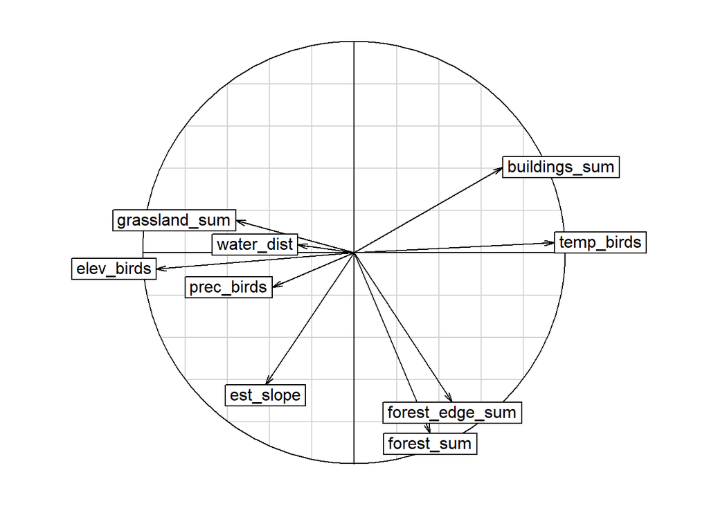

```r
s.corcircle(bird_pca_dudi$co)
```

```r
library(factoextra)
```

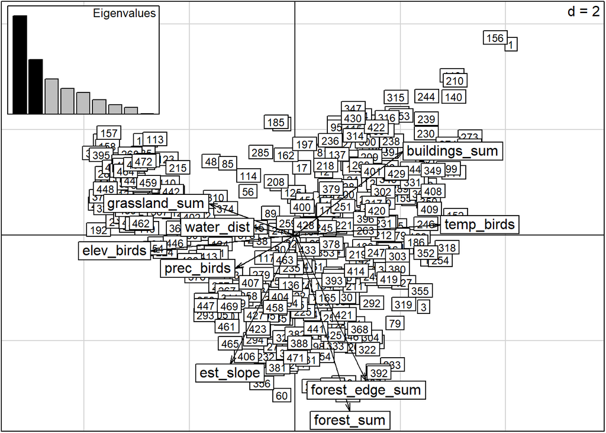

```r
biplot(bird_pca_dudi, cex = 0.1)
```

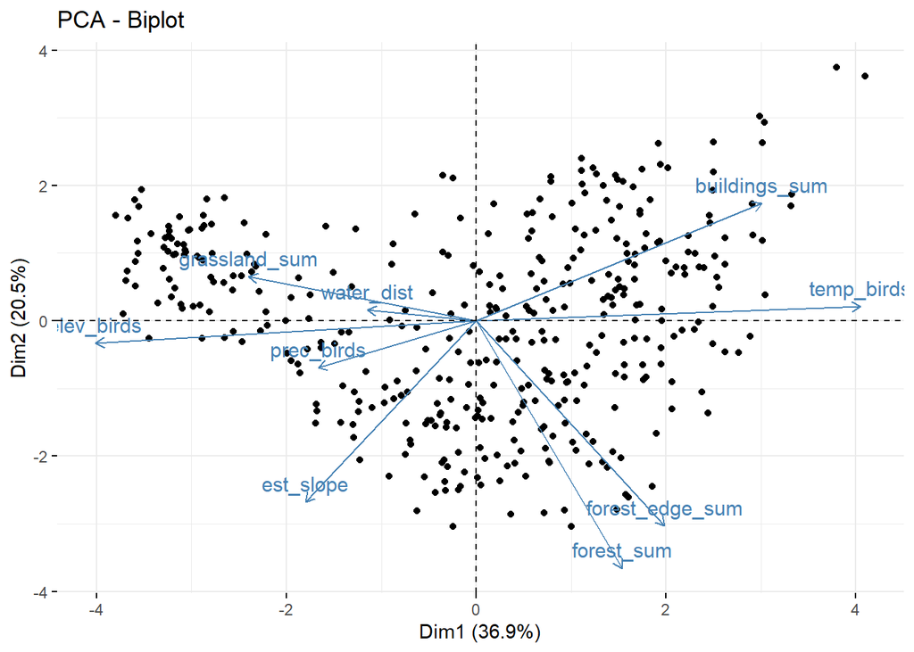

```r
fviz_pca_biplot(bird_pca_dudi, label = "var")
```

To do GLM analsis, I select the top three PCAxes which contibute to over 70% of the data.

```r
top_three_axes <- as.matrix(bird_pca_dudi$co[, 1:3])
new_features <- as.matrix(bird_model_small[, !(colnames(bird_model_small) %in% "species_richness")]) %*% top_three_axes
dim(new_features)
```

```
## [1] 387   3
```

```r
data_for_glm <- data.frame(new_features, species_richness = bird_model_small$species_richness)
glm_model_1 <- glm(species_richness ~ ., data = data_for_glm, family = poisson)

summary(glm_model_1)
```

```
##
## Call:
## glm(formula = species_richness ~ ., family = poisson, data = data_for_glm)
##
## Deviance Residuals:
##     Min       1Q   Median       3Q      Max
## -5.8887  -1.2274   0.1196   1.0147   3.8803
##
## Coefficients:
##               Estimate Std. Error z value Pr(>|z|)
## (Intercept)  3.882e+00  2.411e-02 161.013   <2e-16 ***
## Comp1        5.688e-04  2.084e-05  27.290   <2e-16 ***
## Comp2       -1.858e-03  1.923e-04  -9.662   <2e-16 ***
## Comp3       -3.413e-04  1.853e-05 -18.412   <2e-16 ***
## ---
## Signif. codes:  0 '***' 0.001 '**' 0.01 '*' 0.05 '.' 0.1 ' ' 1
##
## (Dispersion parameter for poisson family taken to be 1)
##
##     Null deviance: 2412.7  on 386  degrees of freedom
## Residual deviance: 1208.9  on 383  degrees of freedom
## AIC: 3257.4
##
## Number of Fisher Scoring iterations: 5
```

```r
#another version using gaussian
glm_model_2 <- glm(species_richness ~ ., data = data_for_glm, family = gaussian)

summary(glm_model_2)
```

```
##
## Call:
## glm(formula = species_richness ~ ., family = gaussian, data = data_for_glm)
##
## Deviance Residuals:
##      Min        1Q    Median        3Q       Max
## -30.4806   -6.1969    0.3028    5.1043   21.0655
##
## Coefficients:
##               Estimate Std. Error t value Pr(>|t|)
## (Intercept) 47.0847848  1.3074041  36.014  < 2e-16 ***
## Comp1        0.0166192  0.0009251  17.964  < 2e-16 ***
## Comp2       -0.0483045  0.0098597  -4.899 1.42e-06 ***
## Comp3       -0.0096826  0.0009017 -10.738  < 2e-16 ***
## ---
## Signif. codes:  0 '***' 0.001 '**' 0.01 '*' 0.05 '.' 0.1 ' ' 1
##
## (Dispersion parameter for gaussian family taken to be 73.69965)
##
##     Null deviance: 66665  on 386  degrees of freedom
## Residual deviance: 28227  on 383  degrees of freedom
## AIC: 2768.3
##
## Number of Fisher Scoring iterations: 2
```